# Module 3

Zaki

## Read the data

Data were downloaded and saved on my local machine in a new folder. So, the first step was to change the working directory to the new one using:

```r
setwd("D:/Courses/HackBio_Contest/module_3/")
```

The second step is to read the data and save them into a variable:

```r
data = read.table("humanGeneticVariationsSamples.tsv", sep = " ", header = T)
```

# Question 1

### How many SNPs are significant (p-value < 0.01) for variability in height(MAF > 0.01) in all the super populations.

To answer this question data were filtered using the following code according to the mentioned parameters.

```r
q1subdata = data[data$EFFECT_ALLELE_FREQ > 0.01 & data$P < 0.01,]
```

To determine if the data slicing is done properly by knowing the range of the required parameters

```r
range(q1subdata$EFFECT_ALLELE_FREQ)
```

```
## [1] 0.0105 1.0000
```

```r
range(q1subdata$P)
```

```
## [1] 0.00000000 0.00999716
```

To determine the number of SNPs that pass the filtration step. Hence, answering the question.

```r
print(length(q1subdata$SNPID))
```

```
## [1] 2253
```

For further insights about how these SNPs are distributed within ancestry data, the data are separated according ancestory and plotted.

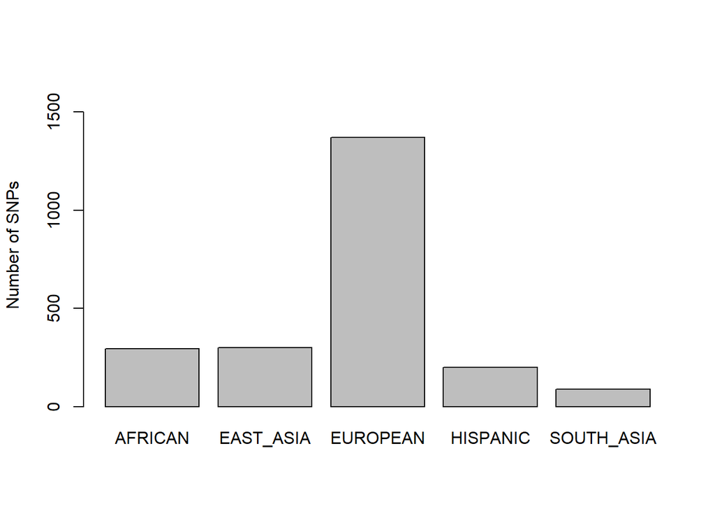

```r
#separate the data according to ancestry
distribution_table = table(as.factor(q1subdata$ANCESTRY))

#plot the number of SNPs in each ancestory
barplot(distribution_table, ylim = c(0, max(distribution_table)*1.20), ylab="Number of SNPs")
```

# Question 2

### How much of Europeans genetic variability can/cannot be found in other super populations. Does this provide enough argument for increasing the diversity of sequencing projects

To answer this question, data were separated into European and non-European ancestory, then counting the number of SNPs that are found in both European and non-European (Repeated SNPs) and the unique SNPs that are found in Europeans only.

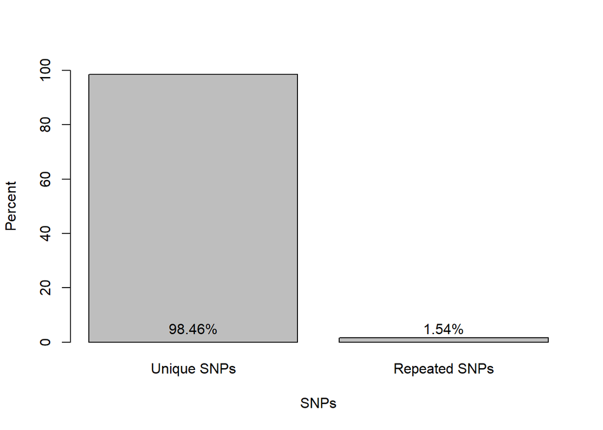

```r
#separate the data
euroSNP = data[data$ANCESTRY == "EUROPEAN",]
otherSNP = data[data$ANCESTRY != "EUROPEAN",]

#define the counting variables
found = 0
notfound = 0

#do the counting process
for (i in euroSNP$RSID){
  if (i %in% otherSNP$RSID){
    found = found + 1
  }else{
    notfound = notfound + 1
  }
}

# calculate the percent
percent_found_SNP = found/length(euroSNP$RSID)*100
percent_notfound_SNP = notfound/length(euroSNP$RSID)*100

#define the plot variable
bp = barplot(c(percent_notfound_SNP, percent_found_SNP),
names.arg = c("Unique SNPs", "Repeated SNPs"), ylim = c(0,100), ylab = "Percent",
xlab = "SNPs")

#add the percent
text(bp, 5, c(sub("$","%",percent_notfound_SNP), sub("$","%",percent_found_SNP)))
```

To get more insights about the importance of increasing the diversity, the SNPs were counted then SNPs with single, double and triple occurance were plotted as the following:

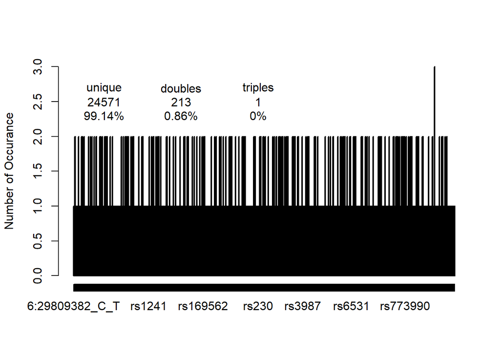

```r
#generate a table of the RSID to determine which is repeated
RSID_table = table(as.factor(data$RSID))

#count
unique_SNPs_no = length(RSID_table[RSID_table == 1])
double_SNPs_no = length(RSID_table[RSID_table == 2])
tripl_SNPs_no = length(RSID_table[RSID_table == 3])

#plot the number of occurrence of each SNP
plt = plot(RSID_table, ylab = "Number of Occurance")
text(2000,2.7,"unique")
text(2000, 2.5, unique_SNPs_no)
text(2000, 2.3, sub("$","%", round(unique_SNPs_no*100/length(RSID_table),2)))
text(7000,2.7,"doubles")
text(7000, 2.5, double_SNPs_no)
text(7000, 2.3, sub("$","%", round(double_SNPs_no*100/length(RSID_table),2)))
text(12000,2.7,"triples")
text(12000, 2.5, tripl_SNPs_no)
text(12000, 2.3, sub("$","%", round(tripl_SNPs_no*100/length(RSID_table),2)))
```

From the calculation and plot, it is found that most sequencing projects in the data got unique SNPs (99.14%) and single SNP were found repeated three times with RSID `rs9370683`

```r
RSID_table[RSID_table == 3]
```

```
## rs9370683
##         3
```

**From the previous, it is highly suggested that increasing the diversity of samples provides more unique data.**

**_____________________________________________________________________________________**

#### during investigationg the data, a question raise into my head which is: “Is SNPs on a specific chromosome correlates with height?”

To answer the question, I wrote the following code:

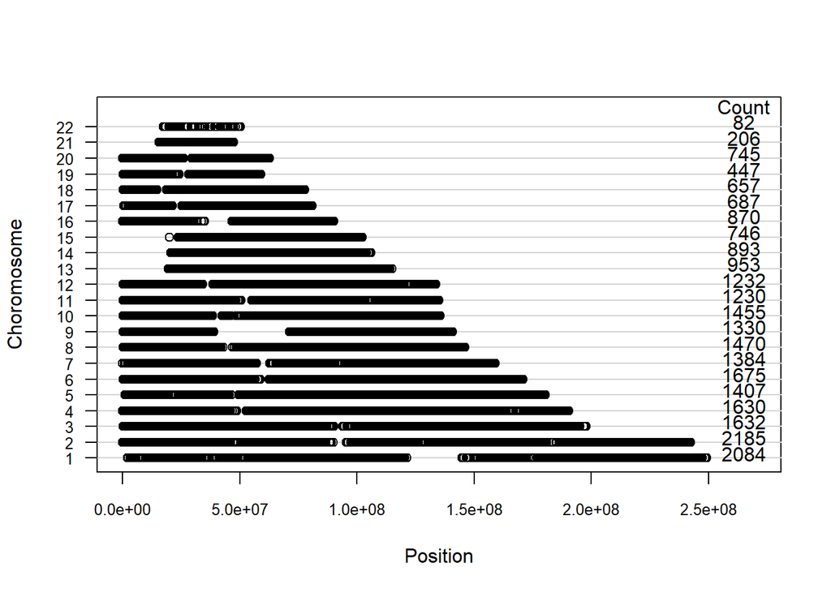

```r
#plot the distribution of SNPs across each chromosome and their count.

plot("", xlim = c(0, 2.7e+08), ylim= c(1,23), yaxp = c(1,22,21),
     xlab= "Position", ylab="Choromosome", las = 1, cex.axis = 0.8 )
abline(h = seq(1, 22, by = 1), col = "lightgray", lty = "solid")

points(data$POS, data$CHR)
for (i in 1:length(as.data.frame(table(as.factor(data$CHR)))[,2])) {
  text(2.65e+08,i+0.3, as.data.frame(table(as.factor(data$CHR)))[i,2])
}
text(2.65e+08,23.3,"Count")
```

after plotting the data it is not clear if SNPs on specific chromosome have a major effect on the height, the difference in the counts may be attributed to the difference in chromosome size. However, in the data only 22 chromosomes are mentioned.